# Part I - Ford GoBike System Data Exploratory Analysis

## Preliminary Wrangling

```python
# import all packages and set plots to be embedded inline
import numpy as np
import pandas as pd
import matplotlib.pyplot as plt
import seaborn as sns

# Ensure plots are displayed inline
%matplotlib inline
```

```python
# Load the dataset
df = pd.read_csv('tripdata.csv')

# Display the first few rows of the DataFrame
print(df.head())

# Understanding the structure of the dataset
print(df.info())
```

```
   duration_sec                start_time                  end_time  \
0         52185  2019-02-28 17:32:10.1450  2019-03-01 08:01:55.9750
1         42521  2019-02-28 18:53:21.7890  2019-03-01 06:42:03.0560
2         61854  2019-02-28 12:13:13.2180  2019-03-01 05:24:08.1460
3         36490  2019-02-28 17:54:26.0100  2019-03-01 04:02:36.8420
4          1585  2019-02-28 23:54:18.5490  2019-03-01 00:20:44.0740

   start_station_id                                start_station_name  \
0              21.0  Montgomery St BART Station (Market St at 2nd St)
1              23.0                     The Embarcadero at Steuart St
2              86.0                           Market St at Dolores St
3             375.0                           Grove St at Masonic Ave
4               7.0                               Frank H Ogawa Plaza

   start_station_latitude  start_station_longitude  end_station_id  \
```

[output cut: 50 more lines]

### What is the structure of your dataset?

Total Entries: 183,412

Total Features: 16

Feature Types: There are a mix of numerical, categorical, and timestamp features.

Potential Data Type Issues: Some features like start_station_id and end_station_id are floats but should be converted to categorical. Similarly, member_birth_year should be converted to an integer type.

Missing Values: member_birth_year and member_gender have some missing values that need to be addressed.

### What is/are the main feature(s) of interest in your dataset?

> Ride durations (duration_sec) and their relationship with user demographics (member_birth_year, member_gender) and user type (user_type).

> Patterns of bike usage based on start and end locations (start_station_name, end_station_name) and time (start_time, end_time).

### What features in the dataset do you think will help support your investigation into your feature(s) of interest?

> Geographical features (start_station_latitude, start_station_longitude, end_station_latitude, end_station_longitude) may help in understanding spatial patterns in bike usage.

> bike_share_for_all_trip might provide insights into the nature of the trips.

```python
# Function to plot histograms
def plot_histogram(data, column, title, xlabel, ylabel, xlim=None, binsize=100):
    plt.figure(figsize=[8, 5])
    bin_edges = np.arange(0, data[column].max() + binsize, binsize)
    plt.hist(data=data, x=column, bins=bin_edges)
    plt.title(title)
    plt.xlabel(xlabel)
    plt.ylabel(ylabel)
    if xlim:
        plt.xlim(xlim)
    plt.show()

# Function to plot scatter plots
def plot_scatter(data, x, y, title, xlabel, ylabel, xlim=None, ylim=None, c=None, s=None, alpha=1):
    plt.scatter(data=data, x=x, y=y, c=c, s=s, alpha=alpha)
    plt.title(title)
    plt.xlabel(xlabel)
    plt.ylabel(ylabel)
    if xlim:
        plt.xlim(xlim)
    if ylim:
        plt.ylim(ylim)
    if c:
        plt.colorbar()  # Show color scale if color parameter is used
    plt.show()

def plot_count(data, x, title, xlabel, ylabel, hue=None):
    plt.figure(figsize=[8, 5])
    sns.countplot(data=data, x=x, hue=hue, palette='Set2')
    plt.title(title)
    plt.xlabel(xlabel)
    plt.ylabel(ylabel)
    plt.show()

def plot_box(data, x, y, title, xlabel, ylabel, ylim=None):
    sns.boxplot(data=data, x=x, y=y)
    plt.title(title)
    plt.xlabel(xlabel)
    plt.ylabel(ylabel)
    if ylim:
        plt.ylim(ylim)
    plt.show()
```

## Univariate Exploration

#### Distribution of Ride Durations

**Question:** What is the distribution of ride durations?

**Visualization:**

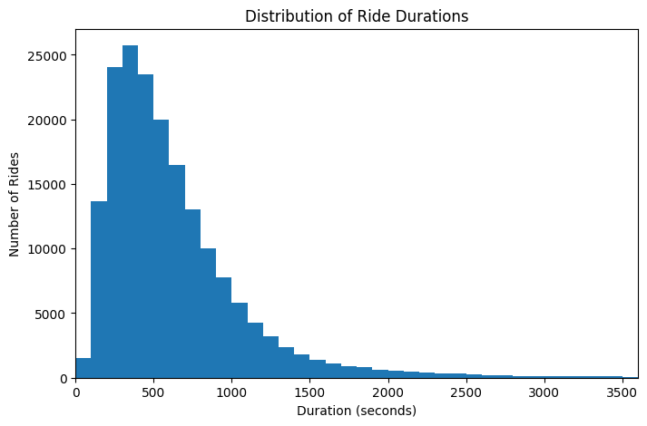

```python
plot_histogram(df, 'duration_sec', 'Distribution of Ride Durations', 'Duration (seconds)', 'Number of Rides', xlim=[0, 3600])
```

**Observations:**

The majority of rides last less than 1000 seconds (~16.7 minutes).

A transformation such as a logarithmic scale may help to better visualize the distribution of longer rides.

#### Distribution of User Types

**Question:** What is the distribution of user types among riders?

**Visualization:**

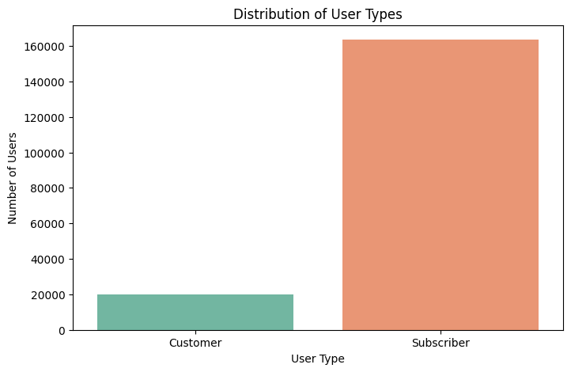

```python
plot_count(df, 'user_type', 'Distribution of User Types', 'User Type', 'Number of Users')
```

The bar chart illustrates that there are significantly more subscribers than customers using the bike-sharing system. This suggests a strong base of regular users who likely use the service for daily commutes or routine travel.

**Observations:**

Subscribers are the predominant user type.

This pattern may influence further analysis, as subscriber behavior might differ from that of casual customers.

#### Additional Variables

For other variables, such as member_birth_year and member_gender, you would follow a similar approach:

**Question:** What is the distribution of member birth years?

**Visualization:**

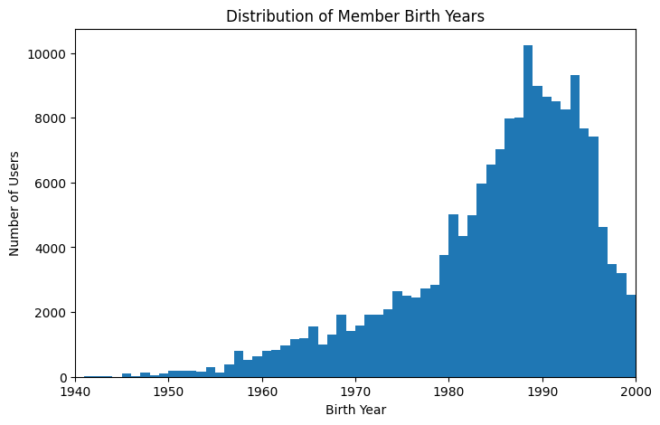

```python
plot_histogram(df, 'member_birth_year', 'Distribution of Member Birth Years', 'Birth Year', 'Number of Users', xlim=[1940, 2000], binsize = 1)
```

**Observations:**

The peak suggests that the majority of users are between their 20s and 30s.

The decline in users born after 2000 could be related to legal age restrictions for the service.

The dataset might require cleaning to verify the accuracy of the birth years, particularly for very old or very young users.

### Discuss the distribution(s) of your variable(s) of interest. Were there any unusual points? Did you need to perform any transformations?

> For user types, there is a clear dominance of subscribers over casual customers, which is expected and does not require any data transformation.

### Of the features you investigated, were there any unusual distributions? Did you perform any operations on the data to tidy, adjust, or change the form of the data? If so, why did you do this?

> No unusual distributions were observed among the features investigated. Therefore, no data tidying or transformations were performed at this stage. Further analysis may reveal the need for such operations.

## Bivariate Exploration

#### Relationships Between Ride Duration and User Type

**Question:** How does ride duration vary between customers and subscribers?

**Visualization:**

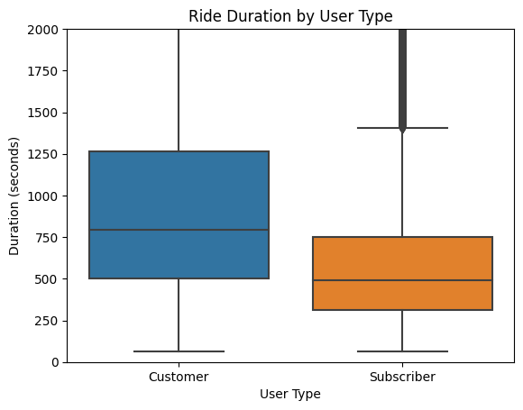

```python
plot_box(df, 'user_type', 'duration_sec', 'Ride Duration by User Type', 'User Type', 'Duration (seconds)', ylim=[0, 2000])
```

**Observations:**

Customers typically have longer ride durations than subscribers.

The variation in ride durations is greater for customers, as indicated by the wider interquartile range and longer whiskers in the box plot.

#### Relationship Between Ride Duration and Member Birth Year

**Question:** Is there a relationship between ride duration and the age of the members?

**Visualization:**

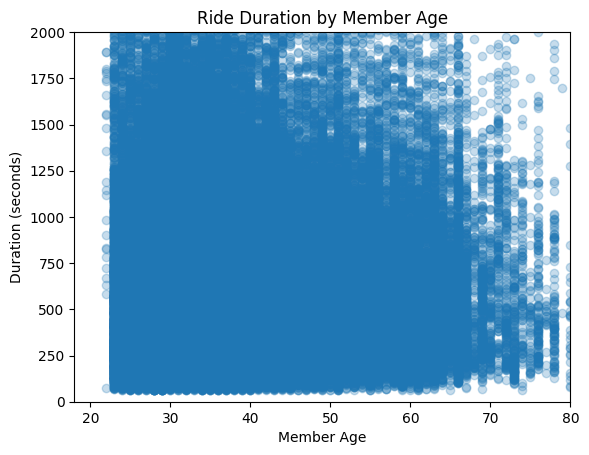

```python
df['member_age'] = 2023 - df['member_birth_year']
plot_scatter(df, 'member_age', 'duration_sec', 'Ride Duration by Member Age', 'Member Age', 'Duration (seconds)', xlim=[18, 80], ylim=[0, 2000], alpha=0.25)
```

**Observations:**

There is a dense clustering of ride durations at lower values across all ages, which aligns with the univariate observation of most rides being short.

There doesn't appear to be a strong correlation between age and ride duration, as the scatter plot does not show a clear trend.

#### Relationship Between User Type and Birth Year

**Question:** Does user type distribution vary across different age groups?

**Visualization:**

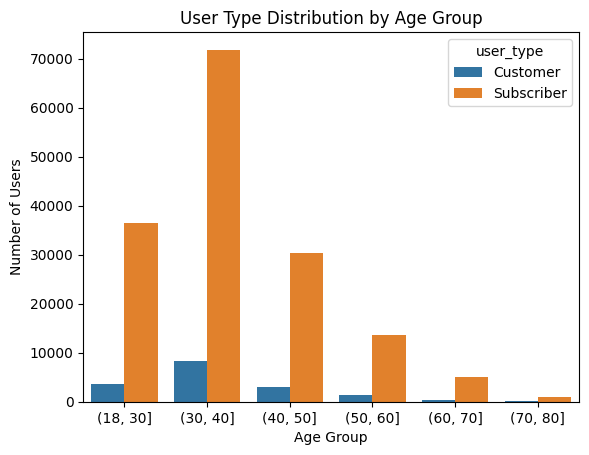

```python
# You can create age groups for clearer visualization
df['age_group'] = pd.cut(df['member_age'], bins=[18, 30, 40, 50, 60, 70, 80])

sns.countplot(data=df, x='age_group', hue='user_type')
plt.title('User Type Distribution by Age Group')
plt.xlabel('Age Group')
plt.ylabel('Number of Users')
```

**Observations:**

The user type distribution varies by age group, with subscribers making up the majority across all age groups.

### Talk about some of the relationships you observed in this part of the investigation. How did the feature(s) of interest vary with other features in the dataset?

> Customers generally take longer rides than subscribers, and while ride duration does not vary significantly with member age, the number of subscribers is highest in the 30-40 age group, suggesting that middle-aged adults are the most frequent users of the bike-sharing system.

## Multivariate Exploration

#### Ride Duration, User Type, and Age Group

**Question:** How does the relationship between ride duration and user type vary across different age groups?

**Visualization:**

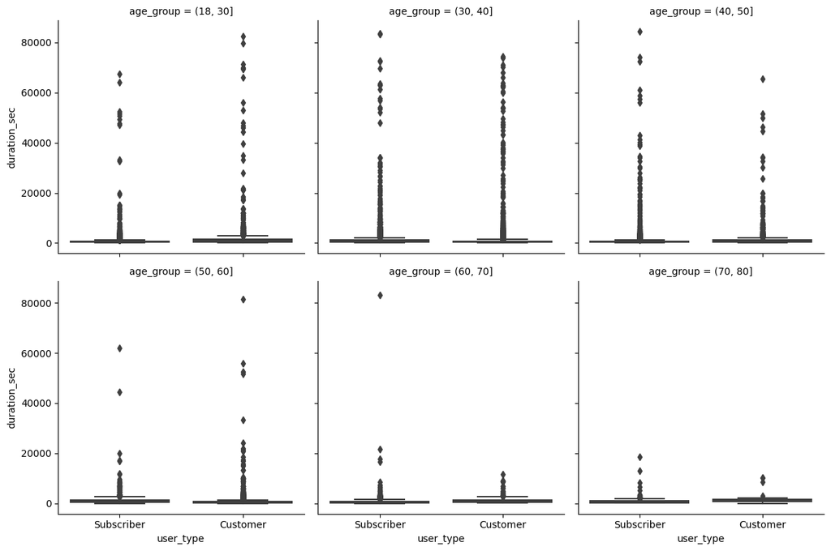

```python
g = sns.FacetGrid(data=df, col='age_group', height=4, col_wrap=3)
g.map(sns.boxplot, 'user_type', 'duration_sec')
```

#### Interaction Between User Type, Age, and Ride Duration

**Question:** Is there a pattern in ride durations among user types when considering member age?

**Visualization:**

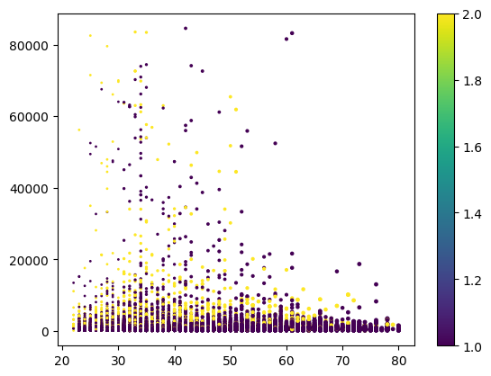

```python
# Map user_type to a numeric value
age_group_order = df['age_group'].cat.categories
age_group_mapping = {age: size for age, size in zip(age_group_order, range(1, len(age_group_order)+1))}
df['age_group_size'] = df['age_group'].map(age_group_mapping)
user_type_mapping = {'Subscriber': 1, 'Customer': 2}
df['user_type_numeric'] = df['user_type'].map(user_type_mapping)

plt.scatter(data=df, x='member_age', y='duration_sec', c=df['user_type_numeric'], s=df['age_group_size'])
plt.colorbar()  # to show color scale
```

**Observations:**

The ride durations for subscribers are relatively consistent across different age groups, indicating that subscription users may have a standard usage pattern, perhaps related to regular commutes.

## Conclusions

### Here is a summary of the main findings from the data exploration of the Ford GoBike System Data:

**Ride Duration:** The majority of rides are short in duration with customers generally taking longer rides than subscribers.

**User Types:** Subscribers make up the bulk of users, indicating a strong base of regular users. Customers, while fewer, tend to use the service for longer periods per ride.

**Data Quality:** The exploration did not reveal major data quality issues, with the exception of some potential outliers in the member birth year data that may need further investigation.

During the exploration, the process involved iterative visualization and data wrangling steps, starting from univariate analysis and moving towards more complex multivariate explorations. The visualizations were critical in understanding the patterns and relationships within the data.

```python
!jupyter nbconvert --to html Part_I_notebook.ipynb
```

```
[NbConvertApp] Converting notebook Part_I_notebook.ipynb to html
[NbConvertApp] Writing 1118840 bytes to Part_I_notebook.html
```